# AIML_ML_Project_Full_Code_Notebook

```python
train_f1_scores = []  # Initialize an empty list to store F1 scores for training set for each decision tree classifier

# Iterate through each decision tree classifier in 'clfs'
for clf in clfs:
    # Predict labels for the training set using the current decision tree classifier
    pred_train = clf.predict(X_train)

    # Calculate the F1 score for the training set predictions compared to true labels
    f1_train = f1_score(y_train, pred_train)

    # Append the calculated F1 score to the train_f1_scores list
    train_f1_scores.append(f1_train)
```

```python
test_f1_scores = []  # Initialize an empty list to store F1 scores for test set for each decision tree classifier

# Iterate through each decision tree classifier in 'clfs'
for clf in clfs:
    # Predict labels for the test set using the current decision tree classifier
    pred_test = clf.predict(X_test)

    # Calculate the F1 score for the test set predictions compared to true labels
    f1_test = f1_score(y_test, pred_test)

    # Append the calculated F1 score to the test_f1_scores list
    test_f1_scores.append(f1_test)
```

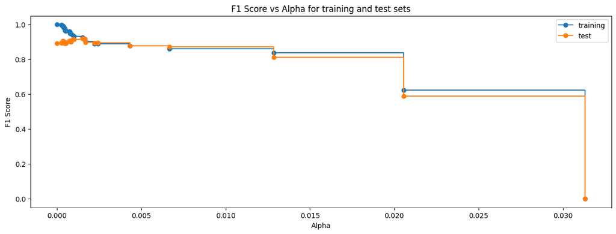

```python
# Create a figure
fig, ax = plt.subplots(figsize=(15, 5))
ax.set_xlabel("Alpha")  # Set the label for the x-axis
ax.set_ylabel("F1 Score")  # Set the label for the y-axis
ax.set_title("F1 Score vs Alpha for training and test sets")  # Set the title of the plot

# Plot the training F1 scores against alpha, using circles as markers and steps-post style
ax.plot(ccp_alphas, train_f1_scores, marker="o", label="training", drawstyle="steps-post")

# Plot the testing F1 scores against alpha, using circles as markers and steps-post style
ax.plot(ccp_alphas, test_f1_scores, marker="o", label="test", drawstyle="steps-post")

ax.legend();  # Add a legend to the plot
```

```python
# creating the model where we get highest test F1 Score
index_best_model = np.argmax(test_f1_scores)

# selcting the decision tree model corresponding to the highest test score
dtree3 = clfs[index_best_model]
print(dtree3)
```

```
DecisionTreeClassifier(ccp_alpha=np.float64(0.0015022145028224059),
                       random_state=42)
```

Checking performance on training data

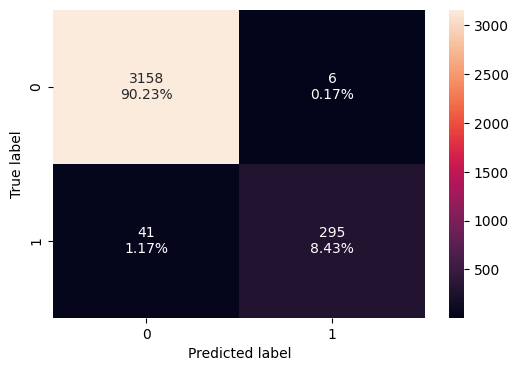

```python
plot_confusion_matrix(dtree3, X_train, y_train)
```

```python
dtree3_train_perf = model_performance_classification(
    dtree3, X_train, y_train
)
dtree3_train_perf
```

|  | Accuracy | Recall | Precision | F1 |
| --- | --- | --- | --- | --- |
| 0 | 0.986571 | 0.877976 | 0.980066 | 0.926217 |

Checking performance on testing data

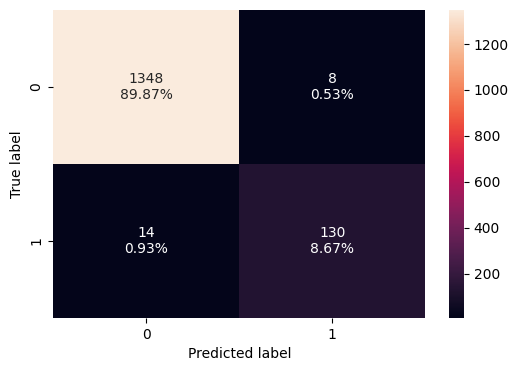

```python
plot_confusion_matrix(dtree3, X_test, y_test)
```

```python
dtree3_test_perf = model_performance_classification(
    dtree3, X_test, y_test
)
dtree3_test_perf
```

|  | Accuracy | Recall | Precision | F1 |
| --- | --- | --- | --- | --- |
| 0 | 0.985333 | 0.902778 | 0.942029 | 0.921986 |

Visualize Decision Tree

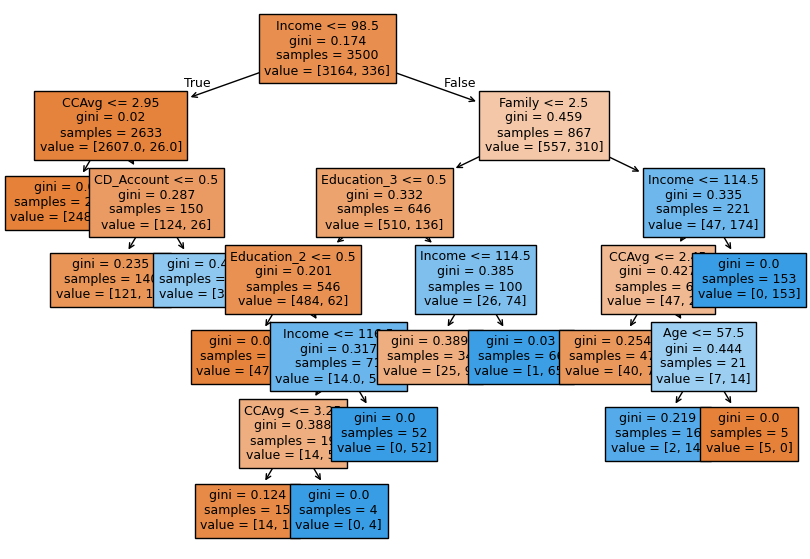

```python
# list of feature names in X_train
feature_names = list(X_train.columns)

# set the figure size for the plot
plt.figure(figsize=(10, 7))

# plotting the decision tree
out = tree.plot_tree(
    dtree3,                         # decision tree classifier model
    feature_names=feature_names,    # list of feature names (columns) in the dataset
    filled=True,                    # fill the nodes with colors based on class
    fontsize=9,                     # font size for the node text
    node_ids=False,                 # do not show the ID of each node
    class_names=None,               # whether or not to display class names
)

# add arrows to the decision tree splits if they are missing
for o in out:
    arrow = o.arrow_patch
    if arrow is not None:
        arrow.set_edgecolor("black")    # set arrow color to black
        arrow.set_linewidth(1)          # set arrow linewidth to 1

# displaying the plot
plt.show()
```

Text Representation of Decision Tree

```python
# printing a text report showing the rules of a decision tree
print(
    tree.export_text(
        dtree3,    # specify the model
        feature_names=feature_names,    # specify the feature names
        show_weights=True    # specify whether or not to show the weights associated with the model
    )
)
```

```
|--- Income <= 98.50
|   |--- CCAvg <= 2.95
|   |   |--- weights: [2483.00, 0.00] class: 0
|   |--- CCAvg >  2.95
|   |   |--- CD_Account <= 0.50
|   |   |   |--- weights: [121.00, 19.00] class: 0
|   |   |--- CD_Account >  0.50
|   |   |   |--- weights: [3.00, 7.00] class: 1
|--- Income >  98.50
|   |--- Family <= 2.50
|   |   |--- Education_3 <= 0.50
|   |   |   |--- Education_2 <= 0.50
|   |   |   |   |--- weights: [470.00, 5.00] class: 0
|   |   |   |--- Education_2 >  0.50
|   |   |   |   |--- Income <= 116.50
|   |   |   |   |   |--- CCAvg <= 3.25
|   |   |   |   |   |   |--- weights: [14.00, 1.00] class: 0
|   |   |   |   |   |--- CCAvg >  3.25
|   |   |   |   |   |   |--- weights: [0.00, 4.00] class: 1
|   |   |   |   |--- Income >  116.50
|   |   |   |   |   |--- weights: [0.00, 52.00] class: 1
|   |   |--- Education_3 >  0.50
|   |   |   |--- Income <= 114.50
|   |   |   |   |--- weights: [25.00, 9.00] class: 0
|   |   |   |--- Income >  114.50
|   |   |   |   |--- weights: [1.00, 65.00] class: 1
|   |--- Family >  2.50
|   |   |--- Income <= 114.50
|   |   |   |--- CCAvg <= 2.45
|   |   |   |   |--- weights: [40.00, 7.00] class: 0
|   |   |   |--- CCAvg >  2.45
|   |   |   |   |--- Age <= 57.50
|   |   |   |   |   |--- weights: [2.00, 14.00] class: 1
|   |   |   |   |--- Age >  57.50
|   |   |   |   |   |--- weights: [5.00, 0.00] class: 0
|   |   |--- Income >  114.50
|   |   |   |--- weights: [0.00, 153.00] class: 1
```

## Model Performance Comparison and Final Model Selection

```python
# training performance comparison

models_train_comp_df = pd.concat(
    [
        dtree1_train_perf.T,
        dtree2_train_perf.T,
        dtree3_train_perf.T,
    ],
    axis=1,
)
models_train_comp_df.columns = [
    "Decision Tree (sklearn default)",
    "Decision Tree (Pre-Pruning)",
    "Decision Tree (Post-Pruning)",
]
print("Training performance comparison:")
models_train_comp_df
```

```
Training performance comparison:
```

|  | Decision Tree (sklearn default) | Decision Tree (Pre-Pruning) | Decision Tree (Post-Pruning) |
| --- | --- | --- | --- |
| Accuracy | 1.0 | 0.981429 | 0.986571 |
| Recall | 1.0 | 0.880952 | 0.877976 |
| Precision | 1.0 | 0.922118 | 0.980066 |
| F1 | 1.0 | 0.901065 | 0.926217 |

```python
# testing performance comparison

models_test_comp_df = pd.concat(
    [
        dtree1_test_perf.T,
        dtree2_test_perf.T,
        dtree3_test_perf.T,
    ],
    axis=1,
)
models_test_comp_df.columns = [
    "Decision Tree (sklearn default)",
    "Decision Tree (Pre-Pruning)",
    "Decision Tree (Post-Pruning)",
]
print("Test set performance comparison:")
models_test_comp_df
```

```
Test set performance comparison:
```

|  | Decision Tree (sklearn default) | Decision Tree (Pre-Pruning) | Decision Tree (Post-Pruning) |
| --- | --- | --- | --- |
| Accuracy | 0.979333 | 0.980000 | 0.985333 |
| Recall | 0.895833 | 0.944444 | 0.902778 |
| Precision | 0.889655 | 0.860759 | 0.942029 |
| F1 | 0.892734 | 0.900662 | 0.921986 |

1. Default Decision Tree (Unpruned)

Still strong accuracy (97.9%) but slightly lower precision and recall balance.

Overfitting is under control compared to the training data (which was perfect), but it’s less stable.

Slightly conservative model—misses some positive cases.

1. Pre-Pruned Decision Tree

Best recall (0.944) — identifies the most loan takers.

Precision is slightly lower (0.861), meaning it produces a few more false positives.

Ideal if marketing wants to reach as many likely customers as possible (broad targeting).

✅ Balanced and generalizes well.

1. Post-Pruned Decision Tree

Highest accuracy (0.9853) and highest precision (0.9420).

Recall is still strong (0.903).

F1 = 0.922 → best overall harmonic balance of precision and recall.

✅ Best if your goal is targeted, cost-efficient campaigns — fewer false leads.

Since our objective is To predict whether a liability customer will buy personal loans - We go ahead with Pre Pruned Model.

Feature Importance

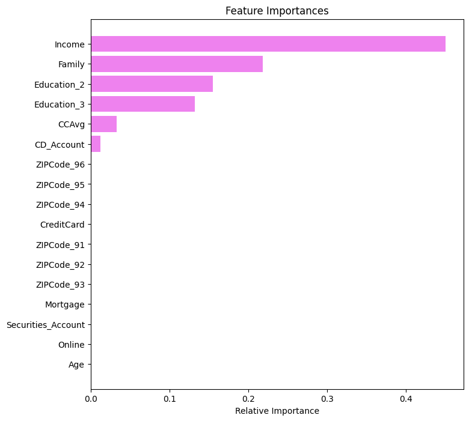

```python
# importance of features in the tree building
importances = dtree2.feature_importances_
indices = np.argsort(importances)

plt.figure(figsize=(8, 8))
plt.title("Feature Importances")
plt.barh(range(len(indices)), importances[indices], color="violet", align="center")
plt.yticks(range(len(indices)), [feature_names[i] for i in indices])
plt.xlabel("Relative Importance")
plt.show()
```

Predicting on a single data point

```python
%%time
# choosing a data point
applicant_details = X_test.iloc[:1, :]

# making a prediction
personal_loan = dtree2.predict(applicant_details)

print(personal_loan)
```

```
[0]
CPU times: user 3.04 ms, sys: 0 ns, total: 3.04 ms
Wall time: 3.01 ms
```

- The model was able to predict in under half a second.
- Instead of predicting a class (approve/reject), the model can also predict the likelihood of approval.

```python
# making a prediction
loan_likelihood = dtree2.predict_proba(applicant_details)

print(loan_likelihood[0, 1])
```

```
0.0
```

## Actionable Insights and Business Recommendations

- What recommedations would you suggest to the bank?
- The bank can deploy this model for the initial screening of liability customers.
- Instead of outputting a yes or no, the model can be made to output the likelihood of approval.
- In case the likelihood of approval is below a certain threshold, say 60%, then the customer can be sent for manual inspection.
- This would reduce the overall TAT for the initial screening.
- Customer attributes - Income, Family, Education , CCAvg are most significant in driving purchases
- Target Customers with age group 35-50 with education as graduate OR Advanced/Professional with higher income and CCAvg.
- Customers with family size 3 also can be put into criteria for target marketing.